# Some Results

Kate Pulham

The scope of the results I wanted to find was to look at the pacific north west and see what sorts of hate crimes are happening there. To do this, I considered hate crimes occuring between the longitudes of -125 and -116, and latitudes of 40 to 49. This included all of Oregon and Washington, and parts of Idaho, Nevada and California. The selection of this window was mostly arbitrary, but it was designed to extend north to Canada, east to the eastern edge of Idaho’s “panhandle” at the northern most point, west enough to not omit any landmass, and south to include the more “PNW-ish” parts of California. This included parts of Nevada as well.

To begin, I plotted the area of interest, a breakdown of which states had the most hate crimess (limited to being within the observation window), those crimes over time, and then the hate crime per capita rate for Washington and Oregon, using census data:

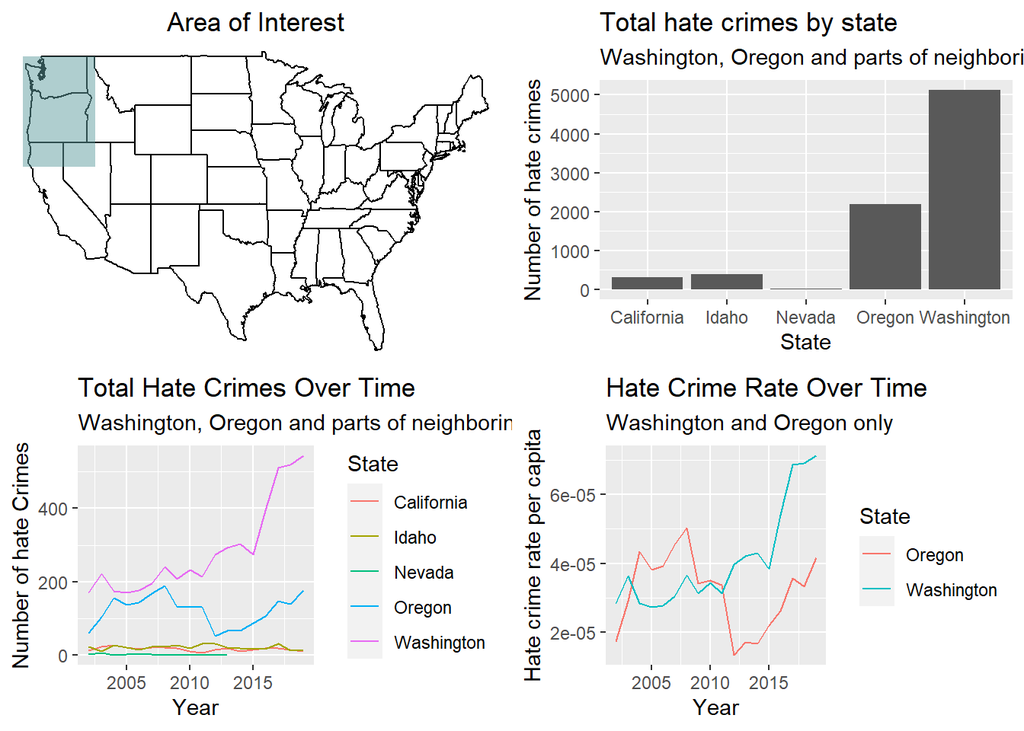

```r
#set up data
load("hate_crime.Rda")
states <- ggplot2::map_data("state")
pnw_hc <- hate_crime%>%
  filter(lat>=40)%>%
  filter(lat<=49)%>%
  filter(lng>=-125)%>%
  filter(lng<=-116)%>%
  filter(DATA_YEAR>=2002)
remove(hate_crime)
census_data <- read.csv("~/masters-project/intercensal_estimates.csv")%>%
  filter(year>=2002)
census_data$hc_count <- rep(NA,length(census_data$year))
for(i in 1:length(census_data$year)){
  gbg <- pnw_hc%>%
    filter(DATA_YEAR==census_data$year[i])%>%
    filter(STATE_NAME==census_data$state[i])
  census_data$hc_count[i] <- length(gbg$ORI)
}
census_data <- census_data%>%
  mutate(hc_rate = hc_count/july1est)

#plots
p1 <- ggplot(pnw_hc)+
  geom_bar(aes(x=STATE_NAME))+
  labs(x="State",y="Number of hate crimes",title="Total hate crimes by state",
       subtitle = "Washington, Oregon and parts of neighboring states")
p2 <- ggplot(pnw_hc)+
  geom_line(aes(x=DATA_YEAR,color=STATE_NAME),stat="count")+
  labs(x="Year",y="Number of hate Crimes",color="State",
       title = "Total Hate Crimes Over Time",
       subtitle="Washington, Oregon and parts of neighboring states")
p3 <- ggplot(census_data,aes(x=year,y=hc_rate,color=state))+
  geom_line()+
  labs(x="Year",y="Hate crime rate per capita",color="State",
       title="Hate Crime Rate Over Time",
       subtitle = "Washington and Oregon only")
p4 <- ggplot()+
  geom_path(data=map_data("state"),aes(x=long,y=lat,group=group))+
  geom_rect(data=NULL,aes(xmin=-125,xmax=-116,ymin=40,ymax=49),
            fill="cadetblue",alpha=0.5)+
  labs(title="Area of Interest")+
  theme_void()+
  theme(plot.title=element_text(hjust=0.5))
ggarrange(p4,p1,p2,p3,nrow=2,ncol=2)
```

I thought the hate crime rate over time plot was particularly interesting.

Next, I fit a GAM to this data. Given that there were 8019 hate crimes for the area of interest during the years of interest, I opted not to do this for the different bias descriptions, since I was concerned to limit the scope of the data even more would make the data too sparse, and would cause the GAM to be overfit. Here’s a plot of the spacio-temporal bins of the data, which will be used as raster data for GAM fitting:

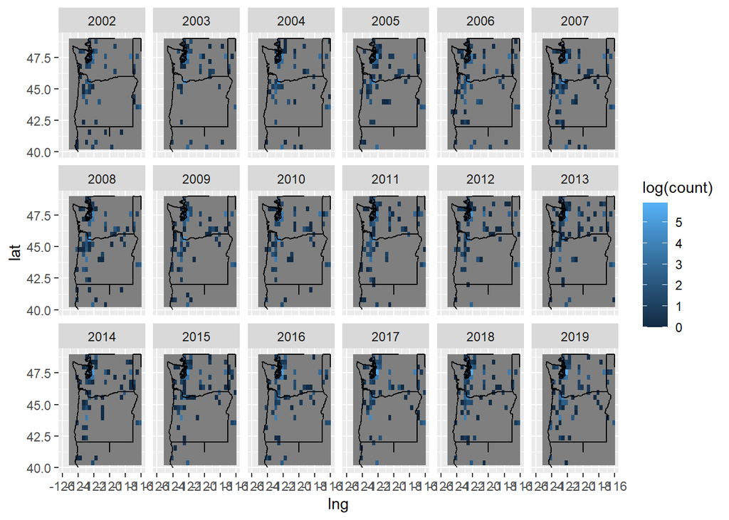

```r
#setting up spaciotemporal bins, count up points
dx=0.2
dy=0.2
lat_max <- 49
lat_min <- 40
lng_max <- -116
lng_min <- -125
X <- seq(from=lng_min,to=lng_max,by=2*dx)
Y <- seq(from=lat_min,to=lat_max,by=2*dy)
Time <-2002:2019
stgrid <- expand.grid(X,Y,Time)
names(stgrid)<-c("lng","lat","year")

#function counts the points in a pixel REQUIRES dx AND dy TO BE DEFINED FIRST
countcrimes<- function(longitude,latitude,year){
  slice <- pnw_hc%>%
    filter(DATA_YEAR==year)%>%
    filter(longitude-dx<=lng)%>%
    filter(lng<=longitude+dx)%>%
    filter(latitude -dy<=lat)%>%
    filter(lat<=latitude+ dx)
  return(length(slice$ORI))
}

#add counts to spaciotemporal grid
stgrid <- stgrid %>%
  mutate(count = pmap_dbl(.l=list(lng,lat,year),.f=countcrimes))

#plot the binned counts:
ggplot(stgrid)+
  geom_raster(aes(x=lng,y=lat,fill=log(count)))+
  facet_wrap(~year,nrow=3)+
  geom_path(data=states,aes(x=long,y=lat,group=group))+
  xlim(-126,-116)+
  ylim(40,49)
```

Now we’re ready to fit the GAM. I spent a decent bit of time tweaking the settings on this, figuring how many knots in both the spatial and temporal dimensions would be a good fit. Initially, too few knots were used, and the spaciotemporal grid was too coarse. This caused the GAM to be underfit in the spatial domain, which can be seen in the following figure:

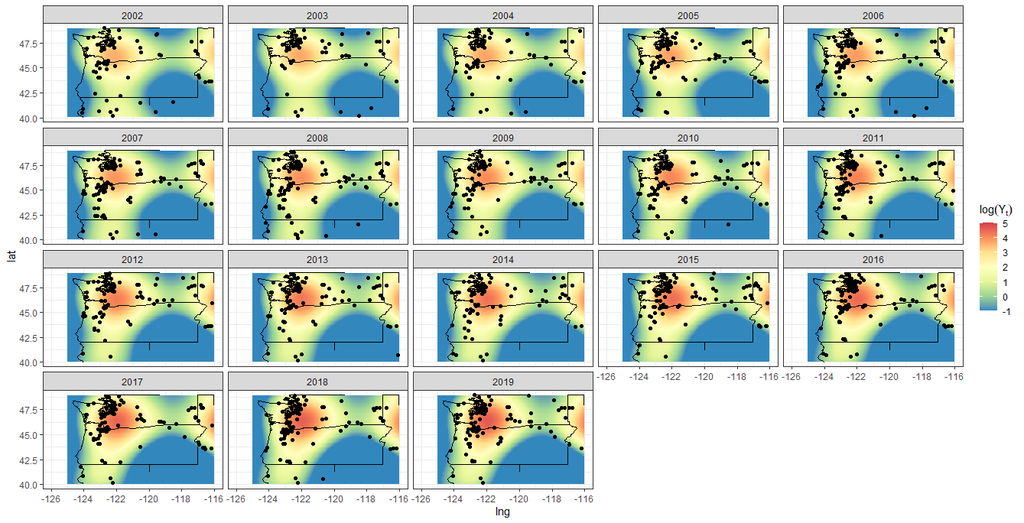

What I ended up using was a 23x23 spatial grid, 50 spatial knots and 10 temporal knots.

```r
#fit the gam
f <- count ~ te(lng, lat, year,        # inputs over which to smooth
                bs = c("tp", "cr"),      # types of bases
                k = c(50, 10),            # knot count in each dimension
                d = c(2, 1))             # (s,t) basis dimension
tic()
cnts <- gam(f, family=nb(link="log"), data=stgrid)
toc()#takes a little over 10 minutes
save(cnts,file="PNW_GAM.Rda")
```

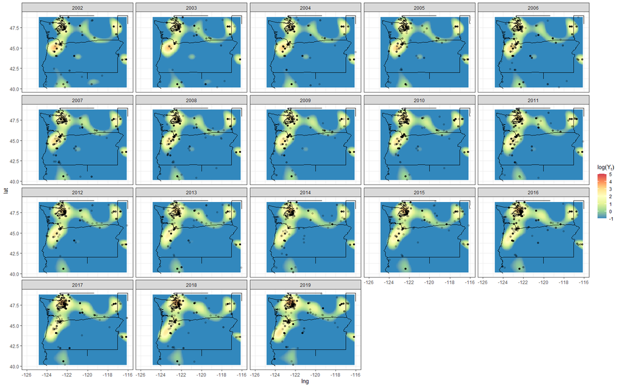

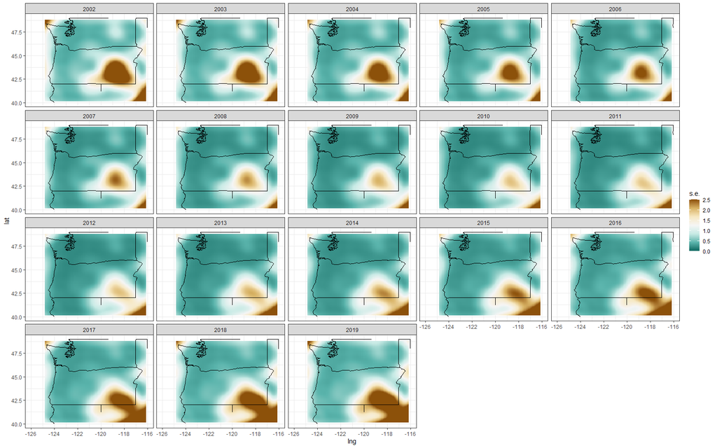

```r
##make model predictions for plotting
grid_locs <- expand.grid(lng = seq(lng_min,lng_max,length.out = 100),
                         lat = seq(lat_min,lat_max,length.out = 100),
                         year = Time)
tic()
X <- predict(cnts, grid_locs, se.fit = TRUE)
toc()
grid_locs$pred <- X$fit
grid_locs$se <- X$se.fit

#plot fitted values
pnw_hc1 <- mutate(pnw_hc,year=DATA_YEAR)
g1 <- ggplot() +
  geom_raster(data = grid_locs,
              aes(lng, lat, fill = pmin(pmax(pred, -1), 5))) +
  facet_wrap(~year, nrow = 4) +
  geom_path(data=states,aes(x=long,y=lat,group=group))+
  geom_point(data=pnw_hc1,aes(x=lng,y=lat),alpha=0.2)+
  fill_scale(limits = c(-1, 5),
             name = expression(log(Y[t]))) +
  col_scale(name = "log(cnt)", limits=c(-1, 5)) +
  xlim(-126,-116)+
  ylim(40,49)+
  theme_bw()

## Plot prediction standard errors
g2 <- ggplot() +
  geom_raster(data = grid_locs,
              aes(lng, lat, fill = pmin(se, 2.5))) +
  facet_wrap(~year, nrow = 4) +
  geom_path(data=states,aes(x=long,y=lat,group=group))+
  fill_scale(palette = "BrBG",
             limits = c(0, 2.5),
             name = expression(s.e.)) +
  # geom_path(data = oregonshape,aes(x=long,y=lat))+
  # geom_path(data = washingtonshape,aes(x=long,y=lat))+
  geom_path(data=states,aes(x=long,y=lat,group=group))+
  xlim(-126,-116)+
  ylim(40,49)+
  theme_bw()

g1
g2
```

I investigated what the temporal component looks like in two spatial locations and I think something is wrong:

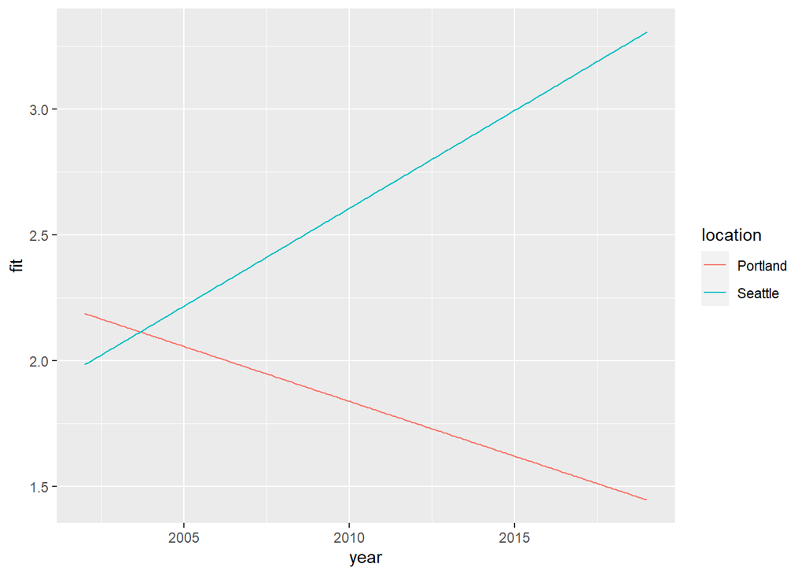

```r
#let's take a look at what's happening in Portland and Seattle
seattle_grid_locs <- expand.grid(lng = -122.3,
                                 lat = 47.6,
                                 year = seq(2002,2019,length.out = 200))
portland_grid_locs <- expand.grid(lng = -122.7,
                                  lat = 45.4,
                                  year = seq(2002,2019,length.out = 200))
Xs <-  predict(cnts, seattle_grid_locs, se.fit = TRUE)
Xp <-  predict(cnts, portland_grid_locs, se.fit = TRUE)
df <- tibble(
  location = c(rep("Seattle",200),rep("Portland",200)),
  year=c(seattle_grid_locs$year,portland_grid_locs$year),
  fit = c(Xs$fit,Xp$fit),
  se  = c(Xs$se.fit,Xp$se.fit)
)%>%
  mutate(ub = fit+se)%>%
  mutate(lb = fit-se)
ggplot(df)+
  geom_line(aes(x=year,y=fit,color=location))
```

How is this model performing though? We can get a residual plot:

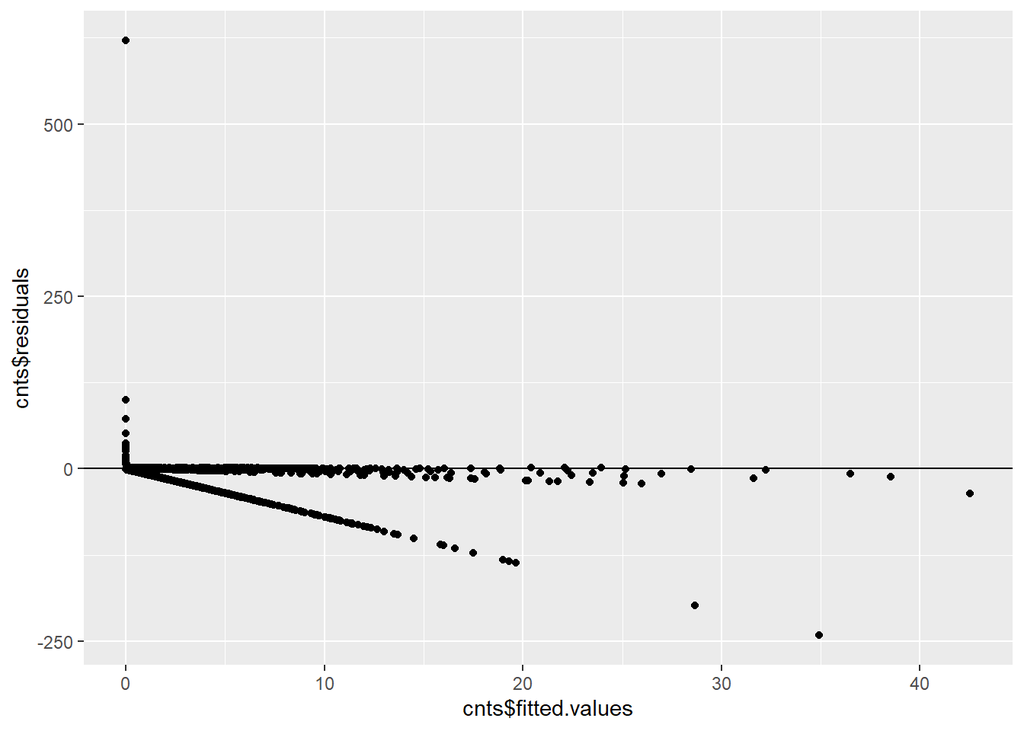

```r
ggplot(data=NULL)+
  geom_point(aes(x=cnts$fitted.values,y=cnts$residuals))+
  geom_hline(yintercept=0)
```

This looks like the model is having issues to me. There are a large number of pixels where zero crimes are predicted but some occurred (seen by the vertical line segment starting at the origin and going upward), and a large number of points where crimes were predicted but none were observed (seen by the diagonal line sloping downward). This, to me, suggests that some degree of overfitting is present.

So what do we do? I can continue to fiddle fart around with the knot count in spatial and temporal domains, or I can look into some model selection with this GAM.